# My TikTok Watching Habits - A Visual Data Story

## About This Story

Every day I scroll through TikTok without really thinking about what I’m watching or when. For this project, I logged 80 TikTok observations over several weeks, recording the content type, video length, how much I watched, and how interested I was. This visual data story explores the patterns in my TikTok habits.

## What Do I Actually Watch?

Not all content is equal on my feed. Comedy and memes dominate, followed closely by advertisements and animal videos. This chart shows the breakdown of the 80 TikToks I logged.

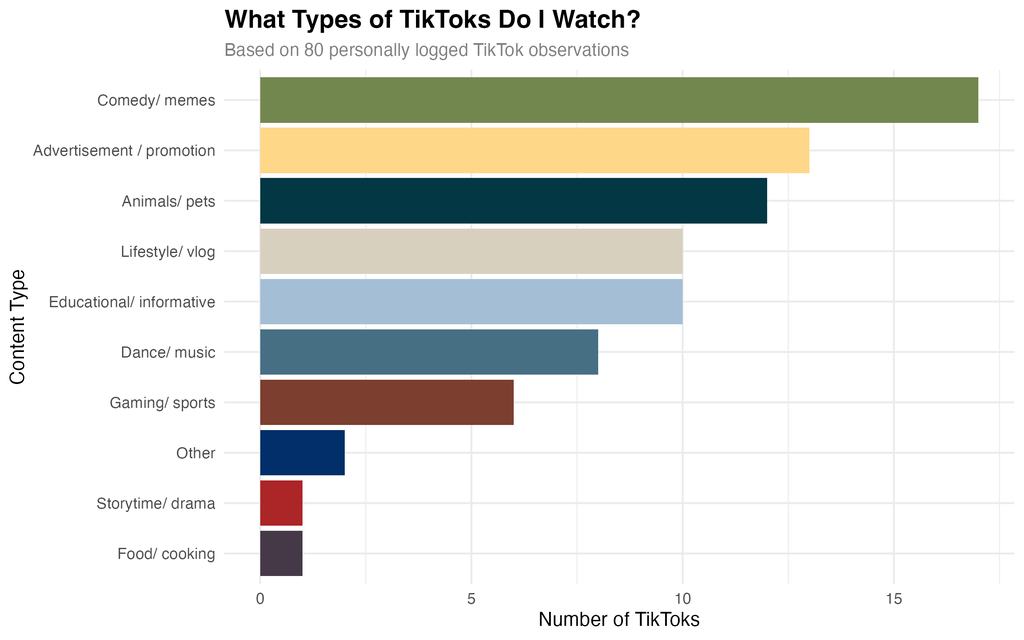

Bar chart showing comedy and memes as the most watched content type, followed by advertisements and animals

## Does Interest Change How Much I Watch?

You might expect that if you’re interested in a video you’d watch more of it — but how strong is that relationship? This boxplot shows the percentage of each TikTok I watched, grouped by how interested I was.

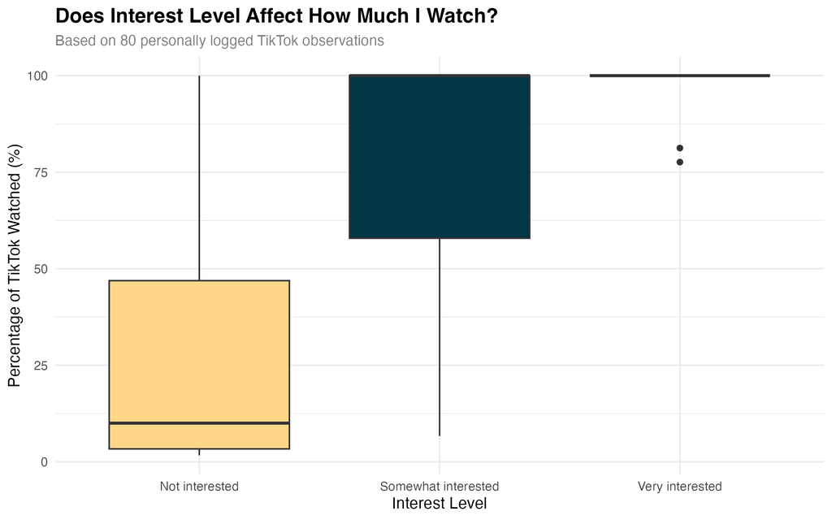

Boxplot showing that very interested TikToks are watched almost fully, while not interested ones are skipped quickly

The pattern is clear — when I’m not interested, I skip quickly (median around 10%), but when I’m very interested I almost always watch the full video.

## When Do I Watch TikTok?

My logging revealed a strong pattern in *when* I use TikTok throughout the day.

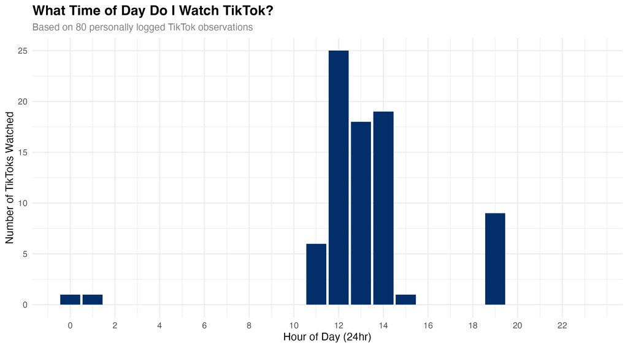

Bar chart showing TikTok usage peaks around midday between 11am and 2pm, with some late night usage

The peak is clearly around lunch time (11am–2pm), with a smaller spike at 7pm. There’s almost no usage in the early morning hours.

## Which Content Has the Longest Videos?

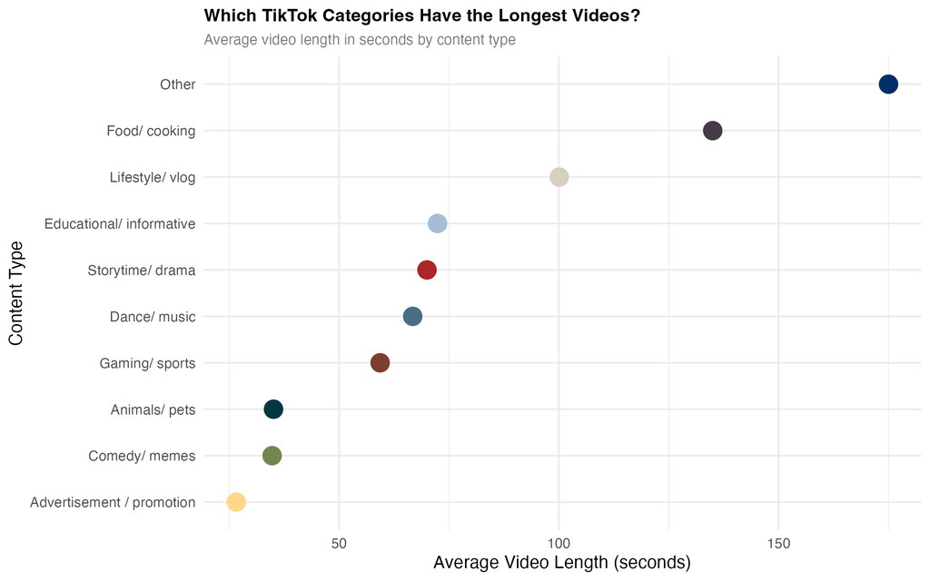